# Association Between First Grade Math Scores and Class Types

Lubaba Ferdous Alim

03/18/2024

# Abstract

By analyzing the Project STAR dataset, it was found that students of small class size of approximately 15-17 show a higher math scaled scores in grade 1 compared to classes of regular size and regular size with aide. Among many, the most important policy that was recommended to schools to adopt was to intervene and maintain a small class size from early grades and maximize the benefits of class size reduction. (Achilles 2012)

# Introduction

The randomized, longitudinal study known as The Tennessee Student Teacher Achievement Ratio (STAR) was conducted between 1985 to 1989 led to identify the long-term positive impacts small sized classrooms have on pupils. The study invited all K-3 Tennessee schools to participate with the condition to be able to form at least one of the three class types: small, regular and regular with a full-time teacher aide.

Using the STAR dataset, this project aims to find answers to two questions of interest:

1. The first is to see if there is any difference in the math scaled scores across grade 1 students as a result of different class types.
2. If yes, the second is to see which class type is associated with the highest math scaled scores in 1st grade.

The motivation behind this analysis lies in finding out whether there is an association between class size and the performance of students to identify and recommend policy actions that will cause long term benefits for students as well the society.

# Background

The State Department of Education conducted a four-year longitudinal study known as The Student/Teacher Achievement Ratio (STAR) in the late 1980s funded by the Tennessee General Assembly (Achilles et al. 2008). The dataset used in this analysis has been obtained from Harvard Dataverse (Achilles et al. 2008). The study adopted the following sampling mechanism: (Achilles 2012)

1. On average just under 7000 students per grade from approximately 79 schools participated in this experiment. The full dataset includes 379 variables for 11601 students.
2. To ensure that sample included students from different socio-economic backgrounds, schools from inner-city, suburban, urban and rural locations were included.
3. To avoid bright students and exemplary teachers from having an effect on test scores, they were randomly assigned to different class types.

Moreover, the study had some additional features: (Achilles 2012)

1. Information of students were only disclosed to principal investigators as well as their staff, wherein only aggregate reports of students’ results were disclosed to secure a pupil’s demographic and individual test-score data.
2. Prior to Project STAR, students were enrolled in regular sized class with number of pupils ranging from approximately 22-25. As a result, this ensured that no children received less of a service by participating in STAR.
3. During the time of the standardized test, it was ensured that no teachers assisted the pupils to complete their exams.
4. To ensure guaranteed impartial results, the statistician, Jeremy Finn, who later analyzed the study, was chosen because he had no participation in the study and had no contact with the principal investigators and staff.

The short-term effect of small class size was seen to benefit almost all students, especially students with low income background, minority, and male students. They were seen to benefit from small class sizes with better test results and school participation as well as reduced grade retention and dropouts.

In this project, we perform descriptive and inferential analysis on a subset of the STAR dataset to study the association between class size and math scaled scores of grade 1 students and address the proposed questions of interest.

Since we are only interested in the grade 1 math scale sores of the students, the variables chosen are as listed in Table 1.

Table 1: Chosen Variables

| Variable Name | Description | Levels |
| --- | --- | --- |
| g1dchid | Grade 1 School ID |  |
| g1surban | School urbanicity grade 1 | 1 = Inner city 2 = Suburban 3 = Rural 4 = Urban |
| g1tchid | Grade 1 Teacher ID |  |
| g1thighdegree | Teacher highest degree grade 1 | 2 = Bachelors 3 = Masters 5 = Specialist 6 = Doctoral |
| g1tcareer | Teacher career ladder level grade 1 | 1 = Choose not to be on career ladder 2 = Apprentice 3 = Probation 4 = Ladder level 1 5 = Ladder level 2 6 = Ladder level 3 |
| g1tyears | Years of total teaching experience grade 1 |  |
| g1classtype | Grade 1 Class Type | 1 = Small class 2 = Regular class 3 = Regular class with aide |
| g1classsize | Class size grade 1 |  |
| g1tmathss | Total math scale score SAT grade 1 |  |

# Data Pre-Processing

```r
#loading data
STAR = read_sav("STAR_Students.sav")
#exploring the variable g1tchid
countNA(STAR$g1tchid)
#checking if there is an overlap of students across different grades
table(STAR$FLAGSGK, STAR$FLAGSG1)
#keep students who were enrolled in project STAR in grade 1
data = subset(STAR, FLAGSG1 == 1)
#Keeping only relevant columns for the analysis
data = data[c('g1schid', 'g1surban', 'g1tchid', 'g1thighdegree', 'g1tcareer', 'g1tyears', 'g1classtype', 'g1classsize', 'g1tmathss')]
#checking the updated dataset
summary(data)
#dropping NAs in g1mathss
data = data[!is.na(data$g1tmathss),]
#checking the updated dataset
summary(data)
#checking if each school has at least one class of each type
(cont_table = table(data$g1schid,data$g1classtype))
cont_table[which(cont_table[,3] == 0), ]
#exclude the schools that do not have "regular+aid" class
no_regular_aid = c(244728,244736,244796,244839)
data = data[-which(data$g1schid %in% no_regular_aid),]

#Checking the type of each variable
sapply(data, class)

data$g1schid = as.factor(data$g1schid)
data$g1surban = as.factor(data$g1surban)
data$g1tchid = as.factor(data$g1tchid)
data$g1thighdegree = as.factor(data$g1thighdegree)
data$g1tcareer = as.factor(data$g1tcareer)
data$g1classtype = as.factor(data$g1classtype)

sapply(data, class)
```

The initial dataset had 11601 students who participated in STAR for at least one year. It contains details of 379 variables ranging from demographic information of students and teachers, school and class identifiers, the three different class assignments, school and teacher information and different test scores.

**Dropping Missing Values:**

- **Missing values in the teacher identifying variable (g1tchid):** In the following analysis, we will be treating each teacher as a basic unit of the analysis to study the association of class size and math scores of first graders. Therefore, we explored the variable g1tchid first. We noticed that there are 4772 missing observations out of the 11601 total. This raised the question of whether 6829 students (11601-4772) were all grade 1 students and the missing observations were pupils from other grades combined. That would be very questionable which is why we checked and confirmed that the 6829 students were those who were either in or those who have already graduated from grade 1 during the time of data collection. Therefore, we dropped the missing values from the original dataset and we were left with observations of students who had grade 1 data.
- **Missing values in the grade 1 math score variable (g1mathss):** Since our response variable was the math scaled score of grade 1 students, missing data of this variable of grade 1 students could mean one of the following: they did not sit for the exam or their exam scores were not recorded. Therefore, these observations were dropped leaving us with 6598 observations.
- **Missing class type “regular + aid” in 4 schools:** The experimental design of STAR required each school to have at least 1 class type in each grade. 4 schools were observed to miss at least 1 class of the class type: regular + aid. Therefore, these schools were dropped from the dataset leaving us with 6334 observations.

# Descriptive Analysis

## **Univariate Summary Statistics**

The following table contains the summary statistics of Quantitative Variables.

```r
#Summary statistics of Quantitative Variables
st(data[,c('g1tmathss','g1tyears', 'g1classsize')], col.breaks = 3,
   summ = list(
     c('countNA(x)', 'mean(x)',   'sd(x)', 'min(x)', 'pctile(x)[25]', 'median(x)', 'pctile(x)[75]', 'max(x)'),
     c('notNA(x)','mean(x)')
   ),
   summ.names = list(
     c('NA','Mean','SD','Min', 'Q1','Median','Q3', 'Max'),
     c('Count','Percent')
   ), labels = c('Grade 1 Math Scores (g1tmathss) ', 'Teachers Total Experience in Grade 1 (g1tyears)', 'Grade 1 Class Size (g1classsize)'),
   title = "Table 2: Summary Statistics of Quantitative Variables")
```

Table 2: Summary Statistics of Quantitative Variables

| Variable | NA | Mean | SD | Min | Q1 | Median | Q3 | Max |
| --- | --- | --- | --- | --- | --- | --- | --- | --- |
| Grade 1 Math Scores (g1tmathss) | 0 | 531 | 43 | 404 | 502 | 529 | 562 | 676 |
| Teachers Total Experience in Grade 1 (g1tyears) | 12 | 12 | 8.8 | 0 | 5 | 10 | 17 | 42 |
| Grade 1 Class Size (g1classsize) | 0 | 21 | 3.9 | 12 | 17 | 22 | 24 | 30 |

Figure 1 below shows the distribution of the categorical variables. We can notice from the distribution of Urbanicity that rural schools (indicated by level 3) were majority of the participant compared to Inner City (1), Suburban (2) and Urban (40). The distribution of the highest degree received by teacher’s seems heavily skewed to the right, indicating most teacher’s of grade 1 having bachelor’s degree (shown by level 2). The distribution of teacher’s career ladder shows a peak at level 4, meaning majority of the grade 1 teacher’s were at career ladder level 1 compared to other levels. Finally, the three class types (small, regular and regular with aide) seem roughly uniformly distributed with regular classes being the highest in number across grade 1 classes.

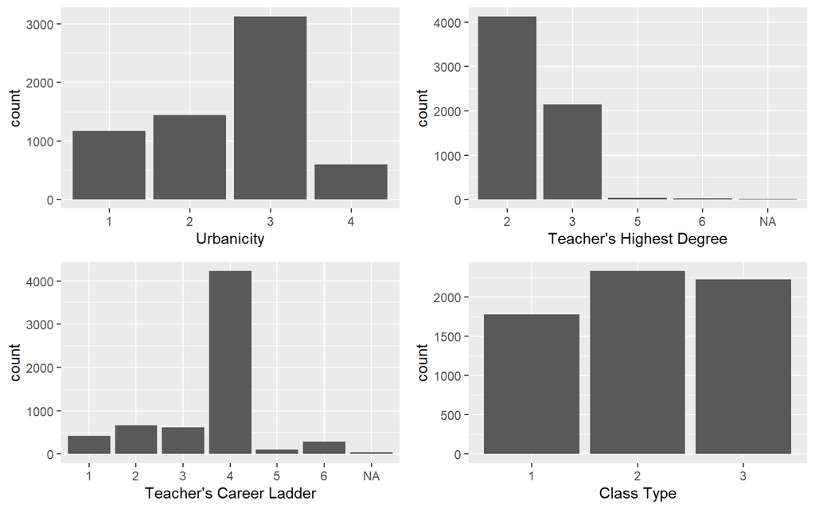

Figure 1: Distribution of Categorical Variables

```r
u = ggplot(data, aes(x = `g1surban`)) +
        geom_bar() + xlab('Urbanicity')
thd = ggplot(data, aes(x = `g1thighdegree`)) +
        geom_bar() + xlab(bquote("Teacher's Highest Degree"))
tcar = ggplot(data, aes(x = `g1tcareer`)) +
        geom_bar() + xlab(bquote("Teacher's Career Ladder"))
ct = ggplot(data, aes(x = `g1classtype`)) +
        geom_bar() + xlab('Class Type')
grid.arrange(u, thd, tcar, ct,
             layout_matrix = matrix(c(1,2,3,4), ncol = 2, byrow = TRUE))
```

It can noticed from the dataset that there are several students who have been assigned to each unique teachers. Since we want to treat each teacher as a statistical unit of measurement, we therefore have to aggregate the students’ math score in grade 1 to get a summary of the scores for each teacher/class. We decided to use quantiles (first quartile, median, and third quartile) as the summary measures, since the median would be less affected by outliers and skewed data compared to mean score, and the first and third quartiles will give us an insight into what effect class size has on the weaker and stronger students in a class respectively. The final dataset for the analysis consists of 325 observations (classes) across 72 schools.

```r
#Using percentile statistics to aggregate the students' math score in grade 1 according to unique teachers
dataset_teacher = data %>%
  group_by(g1schid, g1surban, g1tchid, g1tyears, g1thighdegree, g1tcareer, g1classtype, g1classsize) %>%
  summarise(q1 = quantile(g1tmathss, probs = 0.25),
            med = quantile(g1tmathss, probs = 0.5),
            q3 = quantile(g1tmathss, probs = 0.75))

datatable(head(dataset_teacher))
```

|  | g1schid | g1surban | g1tchid | g1tyears | g1thighdegree | g1tcareer | g1classtype | g1classsize | q1 | med | q3 |
| --- | --- | --- | --- | --- | --- | --- | --- | --- | --- | --- | --- |
| 1 | 112038 | 4 | 11203804 | 7 | 2 | 4 | 3 | 28 | 472 | 479 | 510.5 |
| 2 | 112038 | 4 | 11203805 | 12 | 2 | 4 | 1 | 17 | 488 | 505 | 518 |
| 3 | 112038 | 4 | 11203806 | 5 | 2 | 4 | 2 | 28 | 476.5 | 490 | 521.5 |
| 4 | 123056 | 3 | 12305604 | 10 | 2 | 4 | 2 | 25 | 495 | 523 | 538 |
| 5 | 123056 | 3 | 12305605 | 8 | 3 | 4 | 3 | 27 | 515 | 526 | 562 |
| 6 | 123056 | 3 | 12305606 | 12 | 2 | 4 | 1 | 19 | 523 | 532 | 549 |

Figure 2 below is used to visualize the distribution of the quantile math scores. Left panel: Shows the distribution of the three quantiles of math scores and all three seems roughly normally distributed. Right panel: Shows the distribution of the Quantile math scores against the three class types. For all the quantile levels, we can see that grade 1 students belonging to smaller classes are performing better in math with students in regular classes performing the worst among the three.

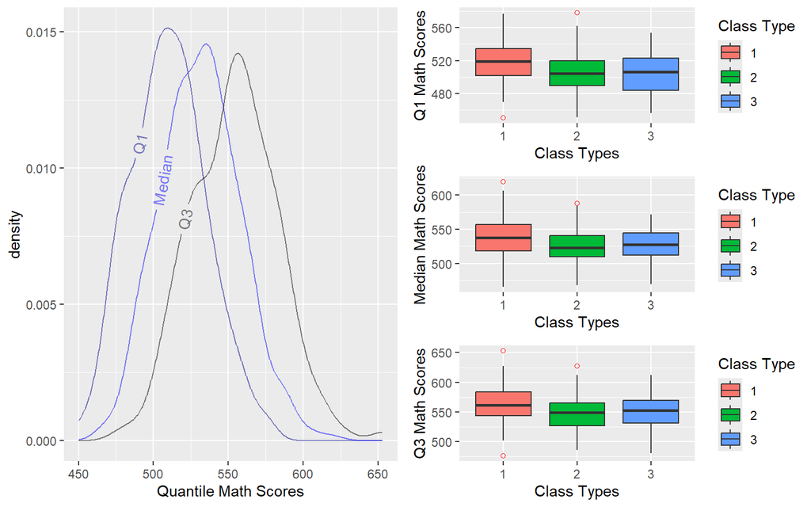

Figure 2: Distribution of Math Scores

```r
# Distribution of Math Scores in Different Quantiles
dis = ggplot(dataset_teacher) +
  xlab("Quantile Math Scores") +
  geom_textdensity(aes(x = q1), colour = 'darkblue', alpha = 0.5, label = 'Q1', hjust = 0.3) +
  geom_textdensity(aes(x = med), colour = 'blue', alpha = 0.5, label = 'Median', hjust = 0.3) +
  geom_textdensity(aes(x = q3), colour = 'black', alpha = 0.5, label = 'Q3', hjust = 0.3)


#Checking the effect of class type on Grade 1 math scores.

#boxplot of Q1 math scores vs. class types
boxplot_score_class = ggplot(dataset_teacher, aes(g1classtype ,q1)) + aes(fill = g1classtype)
ctq1 = boxplot_score_class + geom_boxplot(outlier.colour = "red", outlier.shape = 1) + xlab("Class Types") + ylab("Q1 Math Scores") + scale_fill_discrete(name="Class Type")

#boxplot of Median math scores vs. class types
boxplot_score_class = ggplot(dataset_teacher, aes(g1classtype ,med)) + aes(fill = g1classtype)
ctmed = boxplot_score_class + geom_boxplot(outlier.colour = "red", outlier.shape = 1) + xlab("Class Types") + ylab("Median Math Scores") + scale_fill_discrete(name="Class Type")

#boxplot of Q3 math scores vs. class types
boxplot_score_class = ggplot(dataset_teacher, aes(g1classtype ,q3)) + aes(fill = g1classtype)
ctq3 = boxplot_score_class + geom_boxplot(outlier.colour = "red", outlier.shape = 1) + xlab("Class Types") + ylab("Q3 Math Scores") + scale_fill_discrete(name="Class Type")

grid.arrange(dis, ctq1, ctmed, ctq3,
             layout_matrix = matrix(c(1,2,1,3,1,4), ncol=2, byrow = TRUE))
```

## Multivatiate Analysis

Several multivariate graphs were plotted to understand the association of both the quantitative and qualitative variables with grade 1 math scores.

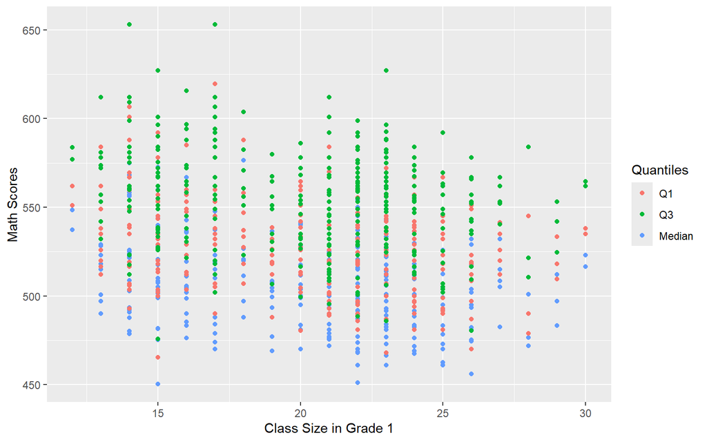

Figure 3: Scatterplot of Math Scores and Class Size

```r
#Scatterplot of Math Scores vs Class Size
ggplot(dataset_teacher, aes(x = g1classsize)) + xlab("Class Size in Grade 1") +
  geom_point(aes(y = q1, col = 'red'), ) +
  geom_point(aes(y = med, col = 'blue')) +
  geom_point(aes(y = q3, col = 'green')) +
  guides(color = guide_legend(title = "Quantiles")) +
  scale_color_discrete(labels = c("Q1", "Q3", "Median")) +
  ylab('Math Scores')
```

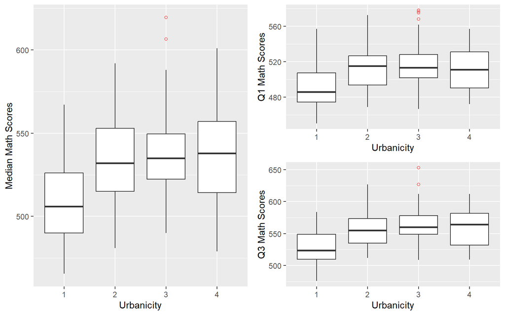

Figure 4: Boxplots of Quantile Math Scores and Urbanicity

```r
#Checking the effect of location on Grade 1 math scores.

#boxplot of Q1 math scores vs. different school location
boxplot_score_class = ggplot(dataset_teacher, aes(g1surban ,q1))
msu1 = boxplot_score_class + geom_boxplot(outlier.colour = "red", outlier.shape = 1) + xlab("Urbanicity") + ylab("Q1 Math Scores")

#boxplot of Median math scores vs. different school location
boxplot_score_class = ggplot(dataset_teacher, aes(g1surban ,med))
msumed = boxplot_score_class + geom_boxplot(outlier.colour = "red", outlier.shape = 1) + xlab("Urbanicity") + ylab("Median Math Scores")

#boxplot of Q3 math scores vs. different school location
boxplot_score_class = ggplot(dataset_teacher, aes(g1surban ,q3))
msu3 = boxplot_score_class + geom_boxplot(outlier.colour = "red", outlier.shape = 1) + xlab("Urbanicity") + ylab("Q3 Math Scores")

grid.arrange(msu1, msumed, msu3,
             layout_matrix = matrix(c(2,1,2,3), ncol = 2, byrow = TRUE))
```

Figure 5 below shows the scatterplot of the quantile math scores against different school ID colour coded by the location of the schools. We cannot visually see any trend between the math scores and different schools.

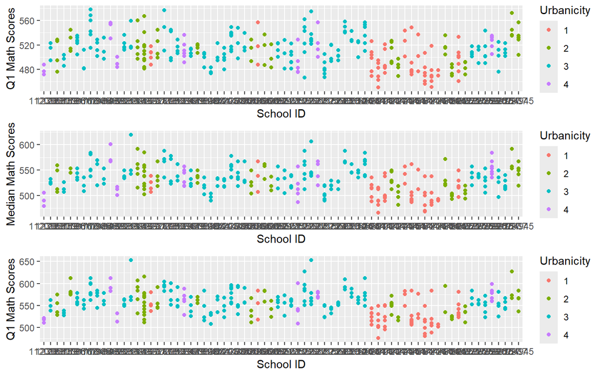

Figure 5: Scatterplot of Quantile Math Scores and School ID colour coded by Urbanicity

```r
#scatterplot of Q1 math scores vs school IDs
s1 = scatterplot_score_schoolID = ggplot(dataset_teacher, aes(g1schid, q1, color = g1surban))+geom_point() + xlab("School ID") + labs(color = "Urbanicity") + ylab("Q1 Math Scores")

#scatterplot of median math scores vs school IDs
s2 = scatterplot_score_schoolID = ggplot(dataset_teacher, aes(g1schid, med, color = g1surban))+geom_point() + xlab("School ID") + labs(color = "Urbanicity") + ylab("Median Math Scores")

#scatterplot of Q3 math scores vs school IDs
s3 = scatterplot_score_schoolID = ggplot(dataset_teacher, aes(g1schid, q3, color = g1surban))+geom_point() + xlab("School ID") + labs(color = "Urbanicity") + ylab("Q1 Math Scores")

grid.arrange(s1, s2, s3,
             layout_matrix = matrix(c(1,2,3)))
```

Several multivariate graphs were plotted to see if there is any association between the quantile math scores and variables related to teachers (g1tyears, g1career and g1thighdegree). We could not see any significant trend between quantile math scores and the teacher variables.

```r
#Scatterplot of math scores vs years of teachers' experience
te = ggplot(dataset_teacher, aes(x = g1tyears)) + xlab("Years of Total Teaching Experience in Grade 1") +
  geom_point(aes(y = q1, col = 'red')) +
  geom_point(aes(y = med, col = 'blue')) +
  geom_point(aes(y = q3, col = 'green')) +
  guides(color = guide_legend(title = "Quantiles")) +
  ylab('Math Scores')

#grid.arrange(te, cs,
             #layout_matrix = matrix(c(1,2)))

#Checking the effect of teacher's degree level on Grade 1 math scores.

#boxplot of Q1 math scores vs. teacher's degree level
boxplot_score_class = ggplot(dataset_teacher, aes(g1thighdegree ,q1))
msd1 = boxplot_score_class + geom_boxplot(outlier.colour = "red", outlier.shape = 1) + xlab("Teacher's Degree Level") + ylab("Q1 Math Scores")

#boxplot of Median math scores vs. teacher's degree level
boxplot_score_class = ggplot(dataset_teacher, aes(g1thighdegree ,med))
msdmed = boxplot_score_class + geom_boxplot(outlier.colour = "red", outlier.shape = 1) + xlab("Teacher's Degree Level") + ylab("Median Math Scores")

#boxplot of Q3 math scores vs. teacher's degree level
boxplot_score_class = ggplot(dataset_teacher, aes(g1thighdegree ,q3))
msd3 = boxplot_score_class + geom_boxplot(outlier.colour = "red", outlier.shape = 1) + xlab("Teacher's Degree Level") + ylab("Q3 Math Scores")

#grid.arrange(cttd1, cttdmed, cttd3,
             #layout_matrix = matrix(c(1,2,3)))

#Checking the effect of teacher's degree level and different class types on Grade 1 math scores.

#boxplot of Q1 math scores vs. teacher's degree level and class types
boxplot_score_class = ggplot(dataset_teacher, aes(g1thighdegree ,q1)) + aes(col = g1classtype)
cttd1 = boxplot_score_class + geom_boxplot(outlier.colour = "red", outlier.shape = 1) + xlab("Teacher's Degree Level") + ylab("Q1 Math Scores")

#boxplot of Median math scores vs. teacher's degree level and class types
boxplot_score_class = ggplot(dataset_teacher, aes(g1thighdegree ,med)) + aes(col = g1classtype)
cttdmed = boxplot_score_class + geom_boxplot(outlier.colour = "red", outlier.shape = 1) + xlab("Teacher's Degree Level") + ylab("Median Math Scores")

#boxplot of Q3 math scores vs. teacher's degree level and class types
boxplot_score_class = ggplot(dataset_teacher, aes(g1thighdegree ,q3)) + aes(col = g1classtype)
cttd3 = boxplot_score_class + geom_boxplot(outlier.colour = "red", outlier.shape = 1) + xlab("Teacher's Degree Level") + ylab("Q3 Math Scores")

#grid.arrange(cttd1, cttdmed, cttd3,
             #layout_matrix = matrix(c(1,2,3)))

#Checking the effect of teacher's career ladder on Grade 1 math scores.

#boxplot of Q1 math scores vs. teacher's career ladder
boxplot_score_class = ggplot(dataset_teacher, aes(g1tcareer ,q1))
msct1 = boxplot_score_class + geom_boxplot(outlier.colour = "red", outlier.shape = 1) + xlab("Teacher's Career Ladder") + ylab("Q1 Math Scores")

#boxplot of Median math scores vs. teacher's career ladder
boxplot_score_class = ggplot(dataset_teacher, aes(g1tcareer ,med))
msctmed = boxplot_score_class + geom_boxplot(outlier.colour = "red", outlier.shape = 1) + xlab("Teacher's Career Ladder") + ylab("Median Math Scores")

#boxplot of Q3 math scores vs. teacher's career ladder
boxplot_score_class = ggplot(dataset_teacher, aes(g1tcareer ,q3))
msct3 = boxplot_score_class + geom_boxplot(outlier.colour = "red", outlier.shape = 1) + xlab("Teacher's Career Ladder") + ylab("Q3 Math Scores")

#grid.arrange(msct1, msctmed, msct3,
             #layout_matrix = matrix(c(1,2,3)))

#Checking the effect of teacher's career ladder and different class types on Grade 1 math scores.

#boxplot of Q1 math scores vs. teacher's career ladder and class types
boxplot_score_class = ggplot(dataset_teacher, aes(g1tcareer ,q1)) + aes(col = g1classtype)
cttc1 = boxplot_score_class + geom_boxplot(outlier.colour = "red", outlier.shape = 1) + xlab("Teacher's Career Ladder") + ylab("Q1 Math Scores")

#boxplot of Median math scores vs. teacher's career ladder and class types
boxplot_score_class = ggplot(dataset_teacher, aes(g1tcareer ,med)) + aes(col = g1classtype)
cttcmed = boxplot_score_class + geom_boxplot(outlier.colour = "red", outlier.shape = 1) + xlab("Teacher's Career Ladder") + ylab("Median Math Scores")

#boxplot of Q3 math scores vs. teacher's career ladder and class types
boxplot_score_class = ggplot(dataset_teacher, aes(g1tcareer ,q3)) + aes(col = g1classtype)
cttc3 = boxplot_score_class + geom_boxplot(outlier.colour = "red", outlier.shape = 1) + xlab("Teacher's Career Ladder") + ylab("Q3 Math Scores")

#grid.arrange(cttc1, cttcmed, cttc3,
             #layout_matrix = matrix(c(1,2,3)))
```

# Inferential Analysis

As our initial model, we define a two-way ANOVA model as follows:

$$Y_{ijk} =
\mu_{..}+\alpha_{i}+\beta_{j}+\epsilon_{ijk}, \\ i = 1,\dots,3 \;j=
1,\dots,72 \;k=1, \dots, 325$$

where

- $i$ represents the class type: small ($i=1$), regular ($i=2$) and regular with aide ($i=3$), $j$ represents the school indicator and $k$ represents the teacher/class and $\sum_{i=1}^{3}n_{i}\alpha_{i} = 0$, and $\sum_{i=1}^{72}n_{j}\beta_{j} = 0$. $\epsilon_{ijk}$ are i.i.d. $N(0,\sigma^{2})$.
- $Y_{ijk}$ represents the median math score of the $i^{th}$ class in the $j^{th}$ school conducted by the $k^{th}$ teacher.
- $\mu_{..}$ represents the weighted average of the cell means.
- $\alpha_i$ represents the factor effect due to the different class sizes ($i=1,2,3$)
- $\beta_{j}$ represents the factor effect due to the different school IDs $j = 1,\dots,72$.
- $\epsilon_{ijk}$ represents the unexplained effects on median math scores for the $k^{th}$ teacher/class in the $j^{th}$ school and $i^{th}$ class type.
- The additive model has been chosen without any interaction term $(\alpha\beta)_{ij}$ because the term would represent any interaction between class type and school ID. However, the experimental design of the project has been done in a such a way to ensure that the effects of the class types on the math score are not due to any factors related to the schools.

```r
lm1.1 = lm(med ~ g1classtype + g1schid, dataset_teacher)
anova_fit1.1 = car::Anova(lm1.1, type = 2)
kbl(anova_fit1.1, caption = "Table 3: two-way fixed effects ANOVA")
```

Table 3: two-way fixed effects ANOVA

|  | Sum Sq | Df | F value | Pr(>F) |
| --- | --- | --- | --- | --- |
| g1classtype | 12364.95 | 2 | 20.326201 | 0 |
| g1schid | 137232.36 | 71 | 6.354655 | 0 |
| Residuals | 76344.88 | 251 | NA | NA |

Fitting the above proposed model (Table 3), we observe that both class type and school ID have $p-value \approx 0$ and are therefore have a significant effect on median math score at a 5% level of significance. However, The effect of the school ID is not something we can easily interpret, and it is only included in the model as a blocking factor to control for the effects of different schools on the math score.

In order to explore the effects of the location of the school in addition to class size, while still controlling for the within school variation, a mixed effects model was defined as follows:

$$Y_{ijkl} = \mu_{...} + \alpha_i +
\beta_j + \gamma_k + \epsilon_{ijkl}, \\ i = 1,\dots,3 \;j= 1,\dots,4
\;k=1, \dots, 72 \;l = 1, \dots, 325$$

where

- $i$ represents the class type: small ($i=1$), regular ($i=2$) and regular with aide ($i=3$), $j$ represents the urbanicity of the school (1 = Inner city, 2 = Suburban, 3 = Rural, 4 = Urban), $k$ represents the school indicator and $l$ represents the teacher/class and $\sum_{i=1}^{3}n_{i}\alpha_{i} = 0$, and $\sum_{i=1}^{72}n_{j}\beta_{j} = 0$. $\epsilon_{ijk}$ are i.i.d. $N(0,\sigma ^2) $
- $Y_{ijk}$ represents the median math score of the class conducted by teacher $l$ in the school $k$, where the urbanicity is $j$ and the class type is $i$.
- $\mu_{..}$ represents the weighted average of the cell means.
- $\alpha_i$ represents the fixed effect due to the different class sizes ($i=1,2,3$), with constraint $\sum \alpha_i =0$
- $\beta_j$ represents the fixed effect due to the urbanicity of the school ($j=1,2,3,4$), with constraint $\sum \beta_j=0$
- $\gamma_k$ id the random intercept corresponding to the $k$th school, with constraint $\gamma_k \sim_{i.i.d.} N(0,\sigma_{\gamma}^2)$
- $\epsilon_{ijkl} \sim_{i.i.d.} N(0, \sigma^2)$ is the random error term
- All random variables are mutually independent.

```r
options(contrasts = c("contr.treatment", "contr.poly"))

lm2.1 = lmer(med ~ g1classtype + g1surban + (1 | g1schid), dataset_teacher)
# summary(lm2.1)

kbl(anova(lm2.1), caption = "Table 4: Mixed Effects Model")
```

Table 4: Mixed Effects Model

|  | Sum Sq | Mean Sq | NumDF | DenDF | F value | Pr(>F) |
| --- | --- | --- | --- | --- | --- | --- |
| g1classtype | 12089.517 | 6044.759 | 2 | 251.60611 | 19.781525 | 0.0000000 |
| g1surban | 5236.215 | 1745.405 | 3 | 65.01378 | 5.711853 | 0.0015603 |

Fitting the proposed mixed effects model (Table 4), it is observed that class type and school urbanicity have $p-value < 0.5$ and therefore have a significant effect on median math score at a 5% level of significance. Before moving forward, we will check if the effects of class type and urbanicity or median math score are additive or interactive.

```r
lm2.2 = lmer(med ~ g1classtype * g1surban + (1 | g1schid), dataset_teacher)
# summary(lm1.2)

kbl(anova(lm2.1, lm2.2), caption = "Table 5: Anova test")
```

Table 5: Anova test

|  | npar | AIC | BIC | logLik | deviance | Chisq | Df | Pr(>Chisq) |
| --- | --- | --- | --- | --- | --- | --- | --- | --- |
| lm2.1 | 8 | 2908.189 | 2938.460 | -1446.095 | 2892.189 | NA | NA | NA |
| lm2.2 | 14 | 2914.600 | 2967.573 | -1443.300 | 2886.600 | 5.589641 | 6 | 0.4706892 |

From the result of the test above (Table 5), we can conclude at a 5% level of significance that class type and school urbanicity have an additive effect on grade 1 median math scores. The reported coefficients of our fitted model is shown below in Table 6.

```r
kbl(summary(lm2.1)$coefficients, caption = "Table 6: Fitted Coefficients")
```

Table 6: Fitted Coefficients

|  | Estimate | Std. Error | df | t value | Pr(>\|t\|) |
| --- | --- | --- | --- | --- | --- |
| (Intercept) | 519.88391 | 5.557776 | 70.68272 | 93.541722 | 0.0000000 |
| g1classtype2 | -12.67554 | 2.362788 | 251.71595 | -5.364654 | 0.0000002 |
| g1classtype3 | -12.98364 | 2.401416 | 251.51424 | -5.406663 | 0.0000001 |
| g1surban2 | 21.04753 | 7.165566 | 63.89773 | 2.937316 | 0.0045994 |
| g1surban3 | 25.62173 | 6.226365 | 63.54613 | 4.115038 | 0.0001136 |
| g1surban4 | 21.93883 | 8.962167 | 64.90839 | 2.447938 | 0.0170807 |

The primary question is to see whether there is any difference in the scores of first graders across the different class types. To check this we can use the F-test at $\alpha=0.05$ significance level.

$$H_0: \alpha_1 = \alpha_2 = \alpha_3 =
0, \; H_a: \text{not all } \alpha_i \text{ are zero}$$

The p-value for this test is 1.05e-08 as shown in Table 4. Therefore we can reject the null and conclude that not all the $\alpha_i$s are zero, meaning there exists some association between math scores and the different class types.

The second question of interest is to check which class type is associated with the highest math scores in grade 1.

We conducted the Tukey-Kramer pairwise comparison test at $\alpha=0.05$ significance level.

$$H_0: \mu_i = \mu_j, \; H_a: \mu_i \ne
\mu_j \text{ where } i,j = 1, 2, 3 \;i\ne j$$

```r
summary(glht(lm2.1, mcp(g1classtype = "Tukey")))
```

```
##
##   Simultaneous Tests for General Linear Hypotheses
##
## Multiple Comparisons of Means: Tukey Contrasts
##
##
## Fit: lmer(formula = med ~ g1classtype + g1surban + (1 | g1schid),
##     data = dataset_teacher)
##
## Linear Hypotheses:
##            Estimate Std. Error z value Pr(>|z|)
## 2 - 1 == 0 -12.6755     2.3628  -5.365   <1e-06 ***
## 3 - 1 == 0 -12.9836     2.4014  -5.407   <1e-06 ***
## 3 - 2 == 0  -0.3081     2.4612  -0.125    0.991
## ---
## Signif. codes:  0 '***' 0.001 '**' 0.01 '*' 0.05 '.' 0.1 ' ' 1
## (Adjusted p values reported -- single-step method)
```

# Sensitivity analysis

From the Normal Q-Q plot shown below, we can see that the distribution of the residuals appears roughly normally distributed for our model.

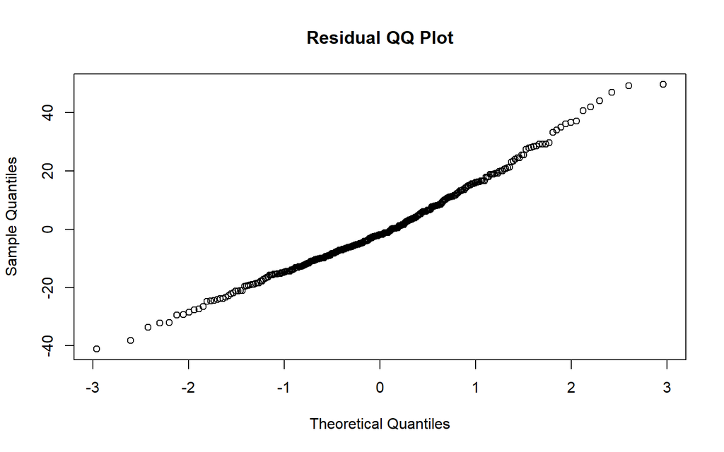

```r
qqnorm(resid(lm2.1), main = "Residual QQ Plot")
```

The Shapiro-Wilks test is conducted to further check the normality assumption of error terms. The p-value for the test as shown below is 0.001056 meaning that at 5% significance level, we can reject the null that the residuals follow a normal distribution and conclude that non-normality exists.

```r
shapiro.test(summary(lm2.1)$residuals)
```

```
##
##  Shapiro-Wilk normality test
##
## data:  summary(lm2.1)$residuals
## W = 0.98389, p-value = 0.001056
```

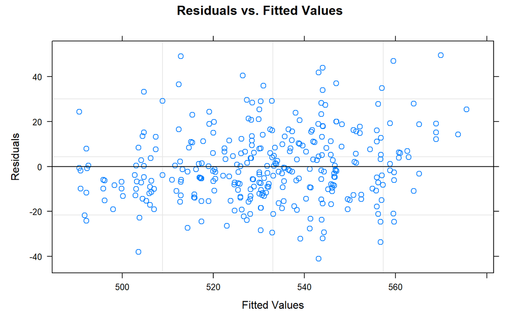

```r
plot(lm2.1, xlab = "Fitted Values", ylab = "Residuals", main = "Residuals vs. Fitted Values")
```

From the residual vs fitted plot shown below, we can observe constancy of error variance.